# Ford GoBike System Data

## Long Le Trung (Brian)

This document explores a dataset containing information about individual rides made in a bike-sharing system covering the greater San Francisco Bay area.

## Preliminary Wrangling

|  | duration_sec | start_time | end_time | start_station_id | start_station_name | start_station_latitude | start_station_longitude | end_station_id | end_station_name | end_station_latitude | end_station_longitude | bike_id | user_type | member_birth_year | member_gender | bike_share_for_all_trip |
| --- | --- | --- | --- | --- | --- | --- | --- | --- | --- | --- | --- | --- | --- | --- | --- | --- |
| 0 | 52185 | 2019-02-28 17:32:10.1450 | 2019-03-01 08:01:55.9750 | 21.0 | Montgomery St BART Station (Market St at 2nd St) | 37.789625 | -122.400811 | 13.0 | Commercial St at Montgomery St | 37.794231 | -122.402923 | 4902 | Customer | 1984.0 | Male | No |
| 1 | 42521 | 2019-02-28 18:53:21.7890 | 2019-03-01 06:42:03.0560 | 23.0 | The Embarcadero at Steuart St | 37.791464 | -122.391034 | 81.0 | Berry St at 4th St | 37.775880 | -122.393170 | 2535 | Customer | NaN | NaN | No |
| 2 | 61854 | 2019-02-28 12:13:13.2180 | 2019-03-01 05:24:08.1460 | 86.0 | Market St at Dolores St | 37.769305 | -122.426826 | 3.0 | Powell St BART Station (Market St at 4th St) | 37.786375 | -122.404904 | 5905 | Customer | 1972.0 | Male | No |
| 3 | 36490 | 2019-02-28 17:54:26.0100 | 2019-03-01 04:02:36.8420 | 375.0 | Grove St at Masonic Ave | 37.774836 | -122.446546 | 70.0 | Central Ave at Fell St | 37.773311 | -122.444293 | 6638 | Subscriber | 1989.0 | Other | No |
| 4 | 1585 | 2019-02-28 23:54:18.5490 | 2019-03-01 00:20:44.0740 | 7.0 | Frank H Ogawa Plaza | 37.804562 | -122.271738 | 222.0 | 10th Ave at E 15th St | 37.792714 | -122.248780 | 4898 | Subscriber | 1974.0 | Male | Yes |
| 5 | 1793 | 2019-02-28 23:49:58.6320 | 2019-03-01 00:19:51.7600 | 93.0 | 4th St at Mission Bay Blvd S | 37.770407 | -122.391198 | 323.0 | Broadway at Kearny | 37.798014 | -122.405950 | 5200 | Subscriber | 1959.0 | Male | No |
| 6 | 1147 | 2019-02-28 23:55:35.1040 | 2019-03-01 00:14:42.5880 | 300.0 | Palm St at Willow St | 37.317298 | -121.884995 | 312.0 | San Jose Diridon Station | 37.329732 | -121.901782 | 3803 | Subscriber | 1983.0 | Female | No |
| 7 | 1615 | 2019-02-28 23:41:06.7660 | 2019-03-01 00:08:02.7560 | 10.0 | Washington St at Kearny St | 37.795393 | -122.404770 | 127.0 | Valencia St at 21st St | 37.756708 | -122.421025 | 6329 | Subscriber | 1989.0 | Male | No |
| 8 | 1570 | 2019-02-28 23:41:48.7900 | 2019-03-01 00:07:59.7150 | 10.0 | Washington St at Kearny St | 37.795393 | -122.404770 | 127.0 | Valencia St at 21st St | 37.756708 | -122.421025 | 6548 | Subscriber | 1988.0 | Other | No |
| 9 | 1049 | 2019-02-28 23:49:47.6990 | 2019-03-01 00:07:17.0250 | 19.0 | Post St at Kearny St | 37.788975 | -122.403452 | 121.0 | Mission Playground | 37.759210 | -122.421339 | 6488 | Subscriber | 1992.0 | Male | No |

```
(183412, 16)
```

```
<class 'pandas.core.frame.DataFrame'>
RangeIndex: 183412 entries, 0 to 183411
Data columns (total 16 columns):
 #   Column                   Non-Null Count   Dtype
---  ------                   --------------   -----
 0   duration_sec             183412 non-null  int64
 1   start_time               183412 non-null  object
 2   end_time                 183412 non-null  object
 3   start_station_id         183215 non-null  float64
 4   start_station_name       183215 non-null  object
 5   start_station_latitude   183412 non-null  float64
 6   start_station_longitude  183412 non-null  float64
 7   end_station_id           183215 non-null  float64
 8   end_station_name         183215 non-null  object
 9   end_station_latitude     183412 non-null  float64
 10  end_station_longitude    183412 non-null  float64
 11  bike_id                  183412 non-null  int64
 12  user_type                183412 non-null  object
 13  member_birth_year        175147 non-null  float64
 14  member_gender            175147 non-null  object
 15  bike_share_for_all_trip  183412 non-null  object
dtypes: float64(7), int64(2), object(7)
memory usage: 22.4+ MB
```

```
duration_sec                 int64
start_time                  object
end_time                    object
start_station_id           float64
start_station_name          object
start_station_latitude     float64
start_station_longitude    float64
end_station_id             float64
end_station_name            object
end_station_latitude       float64
end_station_longitude      float64
bike_id                      int64
user_type                   object
member_birth_year          float64
member_gender               object
bike_share_for_all_trip     object
dtype: object
```

|  | duration_sec | start_time | end_time | start_station_id | start_station_name | start_station_latitude | start_station_longitude | end_station_id | end_station_name | end_station_latitude | end_station_longitude | bike_id | user_type | member_birth_year | member_gender | bike_share_for_all_trip |
| --- | --- | --- | --- | --- | --- | --- | --- | --- | --- | --- | --- | --- | --- | --- | --- | --- |
| 92871 | 1085 | 2019-02-15 18:06:20.5820 | 2019-02-15 18:24:26.0960 | 26.0 | 1st St at Folsom St | 37.787290 | -122.394380 | 97.0 | 14th St at Mission St | 37.768265 | -122.420110 | 4354 | Subscriber | NaN | NaN | No |
| 14513 | 420 | 2019-02-27 12:07:16.4990 | 2019-02-27 12:14:17.3690 | 136.0 | 23rd St at San Bruno Ave | 37.754436 | -122.404364 | 134.0 | Valencia St at 24th St | 37.752428 | -122.420628 | 5351 | Subscriber | 1973.0 | Male | No |
| 32463 | 158 | 2019-02-24 14:27:35.9360 | 2019-02-24 14:30:14.5940 | 276.0 | Julian St at The Alameda | 37.332233 | -121.912516 | 277.0 | Morrison Ave at Julian St | 37.333658 | -121.908586 | 4218 | Subscriber | 1996.0 | Male | Yes |
| 103691 | 256 | 2019-02-14 11:41:02.4200 | 2019-02-14 11:45:18.4440 | 3.0 | Powell St BART Station (Market St at 4th St) | 37.786375 | -122.404904 | 44.0 | Civic Center/UN Plaza BART Station (Market St ... | 37.781074 | -122.411738 | 5369 | Subscriber | 1989.0 | Male | No |
| 130542 | 390 | 2019-02-09 17:00:19.8720 | 2019-02-09 17:06:50.4040 | 47.0 | 4th St at Harrison St | 37.780955 | -122.399749 | 93.0 | 4th St at Mission Bay Blvd S | 37.770407 | -122.391198 | 5218 | Subscriber | 1990.0 | Male | No |

```
duration_sec                  0
start_time                    0
end_time                      0
start_station_id            197
start_station_name          197
start_station_latitude        0
start_station_longitude       0
end_station_id              197
end_station_name            197
end_station_latitude          0
end_station_longitude         0
bike_id                       0
user_type                     0
member_birth_year          8265
member_gender              8265
bike_share_for_all_trip       0
dtype: int64
```

|  | duration_sec | start_station_id | start_station_latitude | start_station_longitude | end_station_id | end_station_latitude | end_station_longitude | bike_id | member_birth_year |
| --- | --- | --- | --- | --- | --- | --- | --- | --- | --- |
| count | 183412.000000 | 183215.000000 | 183412.000000 | 183412.000000 | 183215.000000 | 183412.000000 | 183412.000000 | 183412.000000 | 175147.000000 |
| mean | 726.078435 | 138.590427 | 37.771223 | -122.352664 | 136.249123 | 37.771427 | -122.352250 | 4472.906375 | 1984.806437 |
| std | 1794.389780 | 111.778864 | 0.099581 | 0.117097 | 111.515131 | 0.099490 | 0.116673 | 1664.383394 | 10.116689 |
| min | 61.000000 | 3.000000 | 37.317298 | -122.453704 | 3.000000 | 37.317298 | -122.453704 | 11.000000 | 1878.000000 |
| 25% | 325.000000 | 47.000000 | 37.770083 | -122.412408 | 44.000000 | 37.770407 | -122.411726 | 3777.000000 | 1980.000000 |
| 50% | 514.000000 | 104.000000 | 37.780760 | -122.398285 | 100.000000 | 37.781010 | -122.398279 | 4958.000000 | 1987.000000 |
| 75% | 796.000000 | 239.000000 | 37.797280 | -122.286533 | 235.000000 | 37.797320 | -122.288045 | 5502.000000 | 1992.000000 |
| max | 85444.000000 | 398.000000 | 37.880222 | -121.874119 | 398.000000 | 37.880222 | -121.874119 | 6645.000000 | 2001.000000 |

## Conclusion preprocessing dataset

- Have outliers in member_birth_year which is wrong data in this column with value is 1878.
- Dataset missing values
- Location describe by coordinates lat and long do not have value and not intuitive, maybe need describe by another way.
- In this dataset at columns duration_sec and start_station_id have quite different between mean and min value, but I dont know if are they inacurrate or not

```
(174952, 16)
```

```
location_start 0 nan
location_end 0 nan
location_start 2 nan
location_end 2 nan
location_start 3 nan
location_end 3 nan
```

|  | duration_sec | start_time | end_time | start_station_id | start_station_name | start_station_latitude | start_station_longitude | end_station_id | end_station_name | end_station_latitude | end_station_longitude | bike_id | user_type | member_birth_year | member_gender | bike_share_for_all_trip | location_start | location_end |
| --- | --- | --- | --- | --- | --- | --- | --- | --- | --- | --- | --- | --- | --- | --- | --- | --- | --- | --- |
| 0 | 52185 | 2019-02-28 17:32:10.1450 | 2019-03-01 08:01:55.9750 | 21.0 | Montgomery St BART Station (Market St at 2nd St) | 37.789625 | -122.400811 | 13.0 | Commercial St at Montgomery St | 37.794231 | -122.402923 | 4902 | Customer | 1984.0 | Male | No | NaN | NaN |

```
<class 'pandas.core.frame.DataFrame'>
Index: 174952 entries, 0 to 183411
Data columns (total 18 columns):
 #   Column                   Non-Null Count   Dtype
---  ------                   --------------   -----
 0   duration_sec             174952 non-null  int64
 1   start_time               174952 non-null  datetime64[ns]
 2   end_time                 174952 non-null  datetime64[ns]
 3   start_station_id         174952 non-null  float64
 4   start_station_name       174952 non-null  object
 5   start_station_latitude   174952 non-null  float64
 6   start_station_longitude  174952 non-null  float64
 7   end_station_id           174952 non-null  float64
 8   end_station_name         174952 non-null  object
 9   end_station_latitude     174952 non-null  float64
 10  end_station_longitude    174952 non-null  float64
 11  bike_id                  174952 non-null  object
 12  user_type                174952 non-null  object
 13  member_birth_year        174952 non-null  float64
 14  member_gender            174952 non-null  object
 15  bike_share_for_all_trip  174952 non-null  object
 16  location_start           0 non-null       object
 17  location_end             0 non-null       object
dtypes: datetime64[ns](2), float64(7), int64(1), object(8)
memory usage: 29.4+ MB
```

### What is the structure of your dataset?

> There are 174,952 trips in the dataset with information about when and where the trip started and ended, the duration of each trip, and some information about the user (type, gender, birth year).

The dataset consists of the following columns:

- duration_sec: Duration of the bike ride in seconds (numeric).
- start_time: Timestamp indicating when the ride started (datetime).
- end_time: Timestamp indicating when the ride ended (datetime).
- start_station_id: Identifier for the start station (numeric).
- start_station_name: Name of the start station (categorical).
- start_station_latitude: Latitude of the start station (numeric).
- start_station_longitude: Longitude of the start station (numeric).
- end_station_id: Identifier for the end station (numeric).
- end_station_name: Name of the end station (categorical).
- end_station_latitude: Latitude of the end station (numeric).
- end_station_longitude: Longitude of the end station (numeric).
- bike_id: Identifier for the bike used (numeric).
- user_type: Type of user (categorical; e.g., Subscriber or Customer).
- member_birth_year: Year of birth of the member (numeric; used to calculate age).
- member_gender: Gender of the user (categorical; e.g., Male, Female, Other).
- bike_share_for_all_trip: Indicates whether the ride was part of a bike share program for all trips (categorical).

### What is/are the main feature(s) of interest in your dataset?

The primary features of interest in this dataset are:

- **duration_sec**: This feature is essential for understanding user behavior and ride patterns. It helps analyze how long users typically ride and how this varies across different demographics.
- **user_type**: This feature is important for segmenting users into customers and subscribers, allowing for comparisons in usage patterns and ride durations.
- **member_gender**: Gender can provide insights into differences in riding behavior and preferences between different demographic groups.
- **member_birth_year**: This feature allows us to derive user age, which can be critical for analyzing ride durations and preferences across age groups.

### What features in the dataset do you think will help support your investigation into your feature(s) of interest?

Supporting Features for Investigation Several features in the dataset will help support the investigation into the main features of interest:

- **start_station_name** and **end_station_name:**: These features can provide insights into which stations are most frequently used and whether specific stations attract particular user types or demographics.
- **bike_id**: This can help identify usage patterns for specific bikes, which might be useful for understanding maintenance needs or preferences for certain bikes.
- **bike_share_for_all_trip**: This feature can indicate whether the ride is part of a larger promotional program, which might affect duration and user demographics.

These supporting features will provide a comprehensive context to analyze the main features, allowing for deeper insights into user behavior and preferences in bike-sharing services.

## Univariate Exploration

```
(0.0, 3000.0)
```

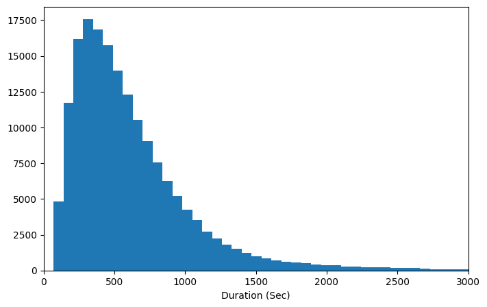

### 2. What does the distribution of ride durations tell us about typical trip lengths in this dataset ?

Shows the frequency of ride durations with a kernel density estimate overlay.

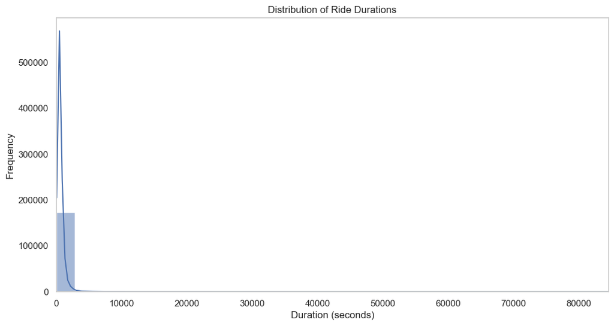

### 3. How different among user types ?

Displays the counts of customer versus subscriber types.

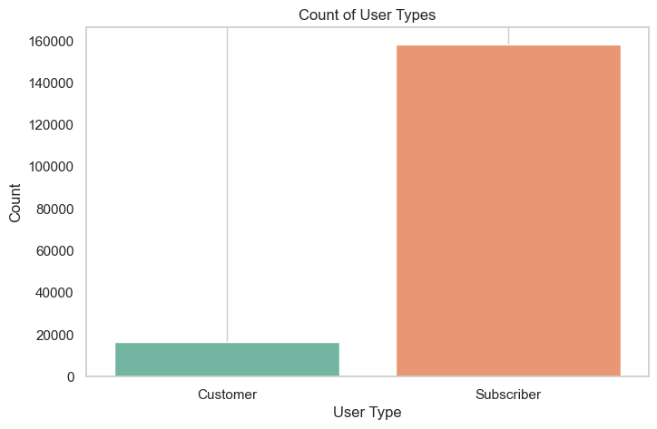

### 4. Count Plot of Gender Distribution

Visualizes the distribution of gender among users.

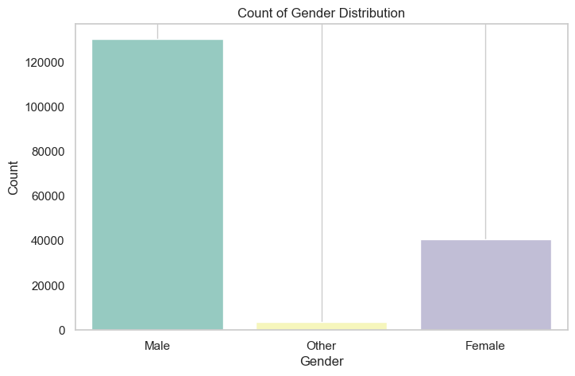

### 5. Why are certain age groups more represented in this dataset, and what factors might explain the popularity of bike-sharing among specific birth year ranges ?

Displays the frequency of users based on their birth year, indicating age distribution.

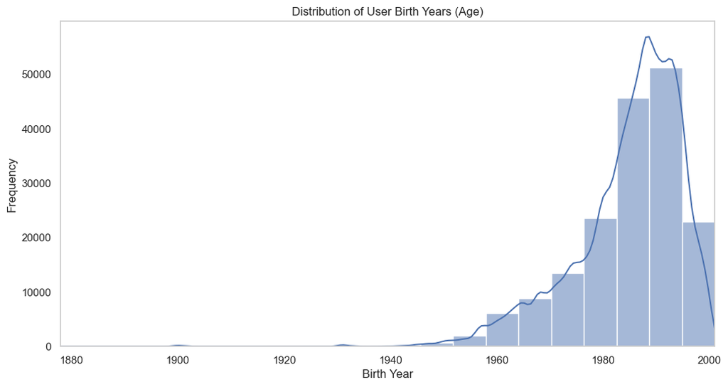

### 6. Why are these specific start stations more frequently used, and how might their locations impact bike-sharing usage patterns ?

Shows the most frequently used start stations in the dataset.

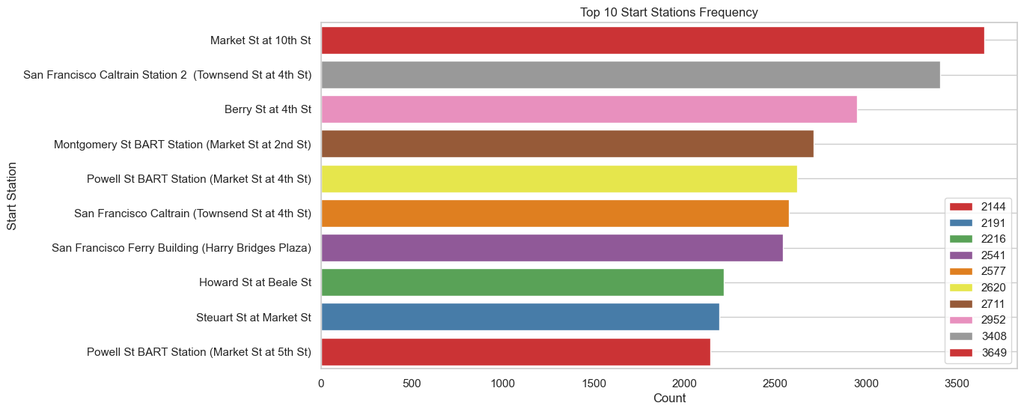

### 7. Why are these specific end stations more frequently used, and how might their locations impact bike-sharing usage patterns?

Highlights the most frequently used end stations.

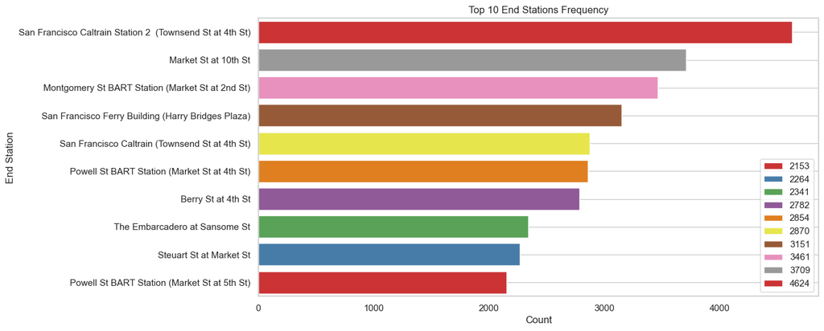

### Discuss the distribution(s) of your variable(s) of interest. Were there any unusual points? Did you need to perform any transformations?

Distribution(s) of Variables of Interest:

- The distribution of ride durations showed a right-skewed pattern, with most rides being relatively short but a few extending into significantly longer durations. This suggests that while the average ride might seem short, there are outliers that skew the mean. The histogram indicated some unusually long rides that may need to be investigated further.
- User type distribution showed a clear predominance of subscribers compared to customers, which indicates a strong base of repeat users.
- The gender distribution displayed a notable imbalance, with a higher count of male users compared to females and others, pointing toward a potential area of interest for targeted marketing.
- The age distribution (based on birth years) was also somewhat skewed, showing a concentration of users in the 20-30 age range, suggesting this demographic is more inclined to use bike-sharing services.

There were no significant transformations needed for the ride duration variable, but the analysis of age might benefit from creating age groups for clearer insights.

### Of the features you investigated, were there any unusual distributions? Did you perform any operations on the data to tidy, adjust, or change the form of the data? If so, why did you do this?

Unusual Distributions and Data Operations:

- The distribution of ride durations was unusual due to the presence of outliers. Although no transformations were needed, it was essential to highlight these outliers for further investigation to ensure they didn't skew the overall analysis or insights derived from this variable.
- The age variable was adjusted by creating age groups (e.g., <20, 20-30, etc.) to facilitate better analysis and visualization. This categorization allows for more straightforward comparisons and insights into ride duration across different age brackets.

## Bivariate Exploration

### 1. How do ride durations differ between Customers and Subscribers, and what might explain these differences?

Compares ride durations for different user types using a box plot.

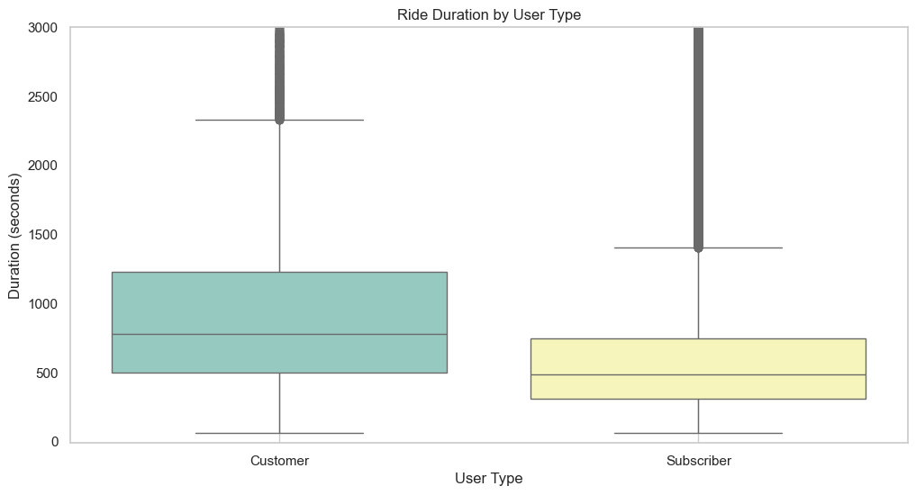

### 2. How does ride duration vary by gender, and are there significant differences in typical ride lengths among different gender groups?

Analyzes the differences in ride durations based on gender.

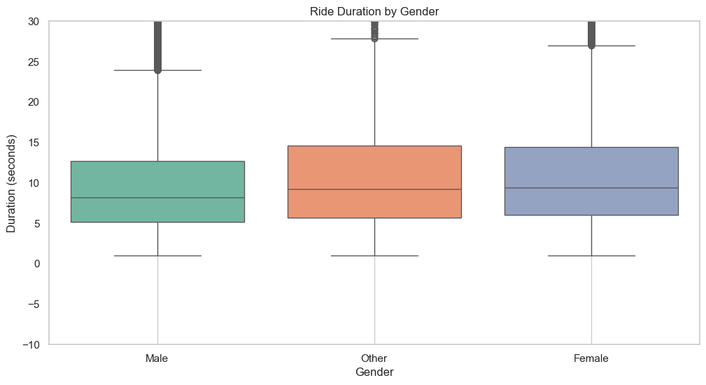

### 3. How does the distribution of user types vary by gender, and why might there be a significant difference in the proportion of male and female subscribers?

Displays the distribution of genders across user types.

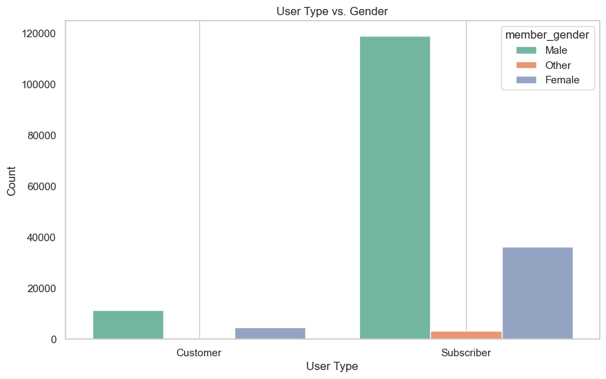

### 4. Why do certain start stations attract more Subscribers than Customers, and what factors might influence these preferences?

Shows the counts of rides from the most popular start stations segmented by user type.

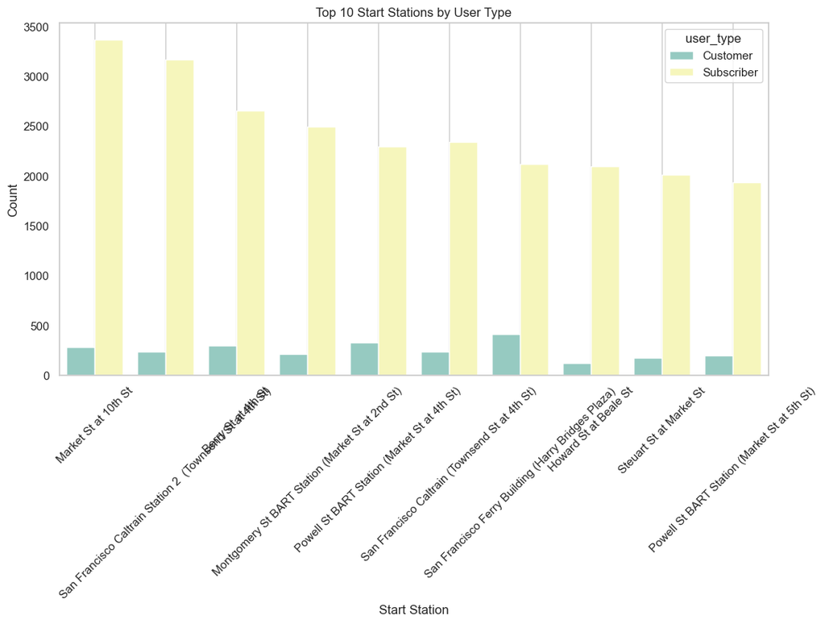

### 5. Why do certain end stations attract more Subscribers than Customers, and what factors might influence these preferences?

Similar to the previous plot, but for end stations.

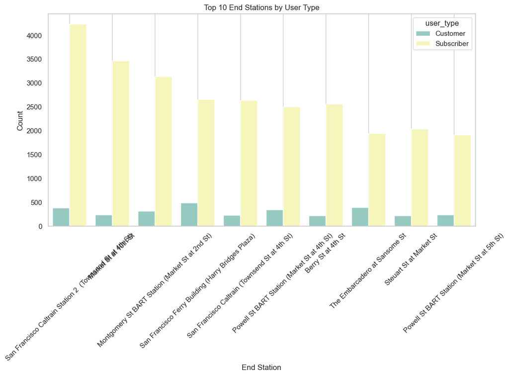

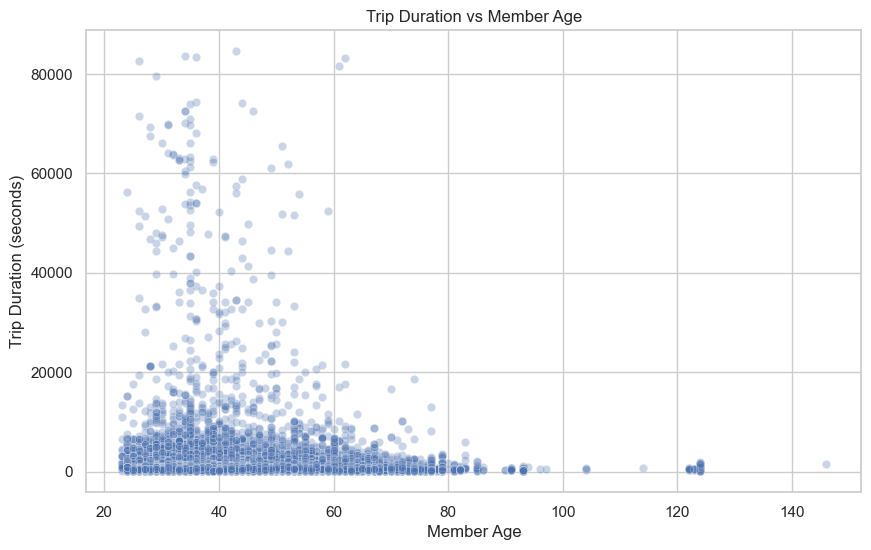

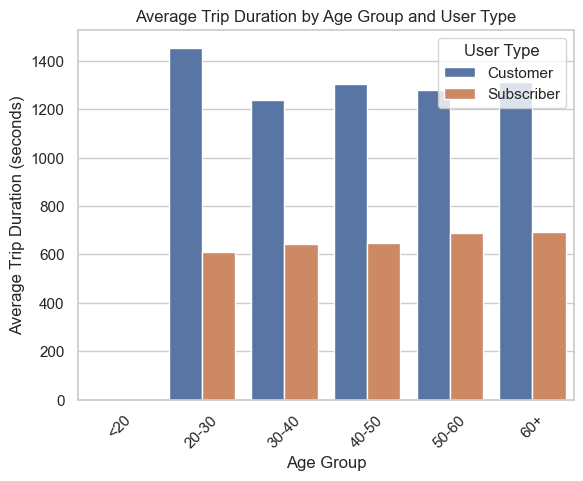

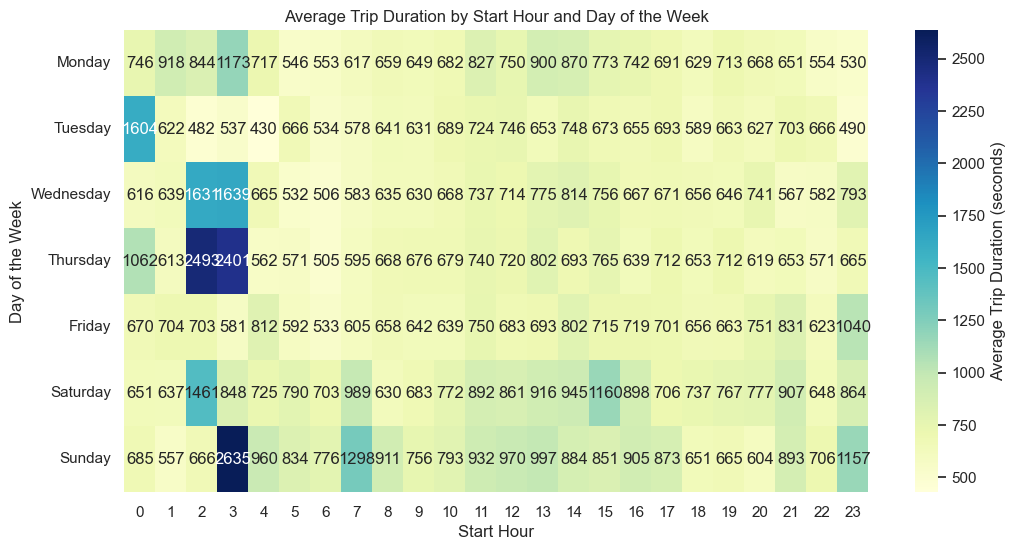

### 7. What does the usage pattern across the top 10 start stations reveal about the preferences of Customers versus Subscribers?

Visualizes the interaction between start stations and user types using a heatmap.

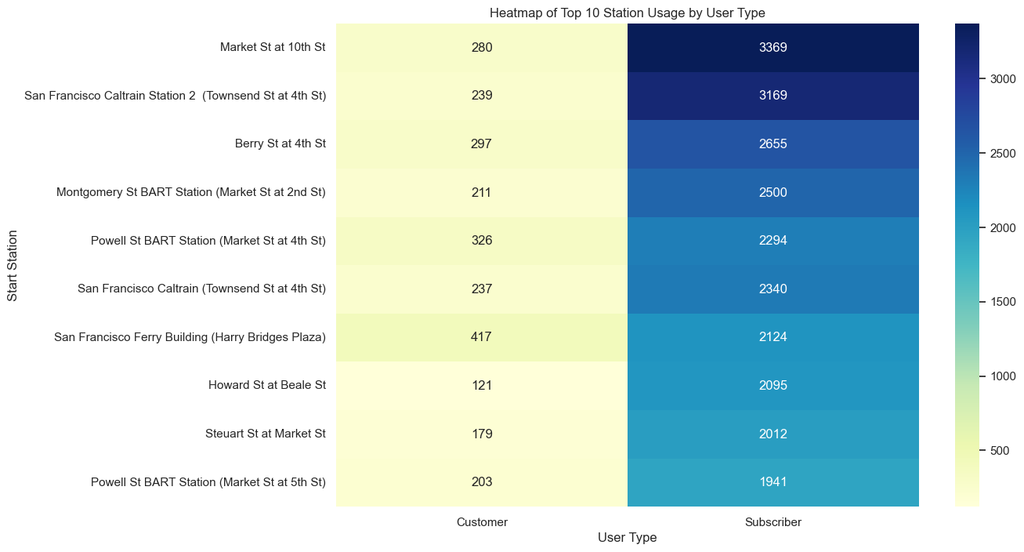

## 8. What does the usage pattern across the bottom 10 start stations reveal about the preferences of Customers versus Subscribers?

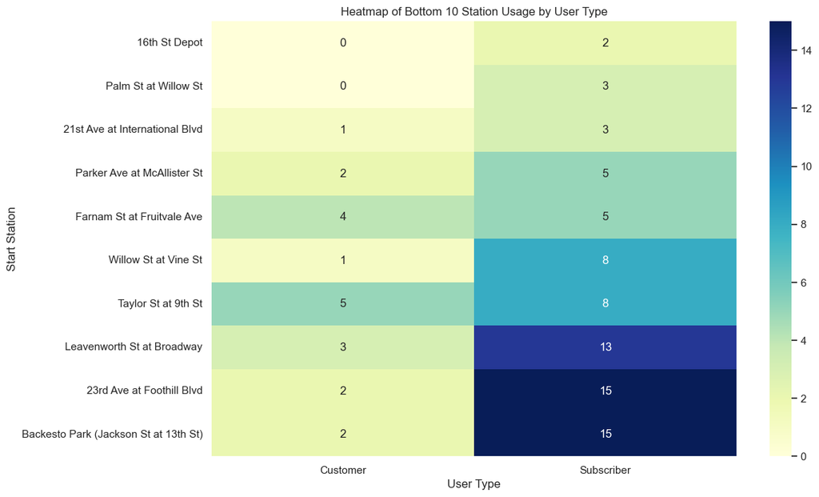

### 8. What does the near-zero correlation between trip duration and member birth year suggest about the relationship between age and trip duration?

Displays correlations between numerical variables, specifically focusing on ride duration and birth year.

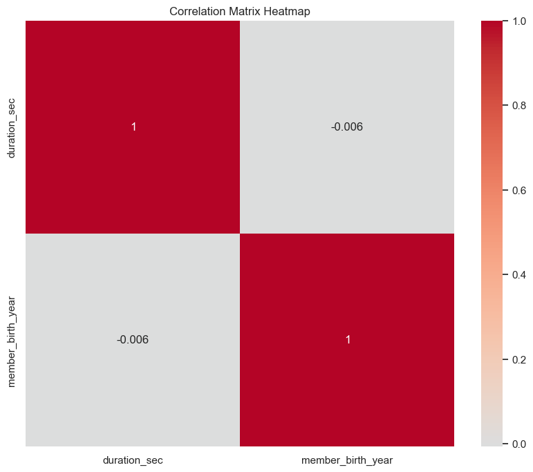

### Did you observe any interesting relationships between the other features (not the main feature(s) of interest)?

Interesting Relationships:

- The count plots comparing user type and gender illustrated that male subscribers formed the largest group, which might suggest that marketing efforts could focus on attracting more female subscribers or encouraging more engagement from underrepresented gender groups.
- The analysis of start and end station usage by user type revealed which stations were favored by customers and subscribers, showing that certain stations cater more to subscribers, hinting at possible operational insights for station management.

## Multivariate Exploration

### 1. How does ride duration vary across gender groups within each user type, and are there noticeable differences between Customers and Subscribers?

Examines how ride duration varies by both user type and gender.

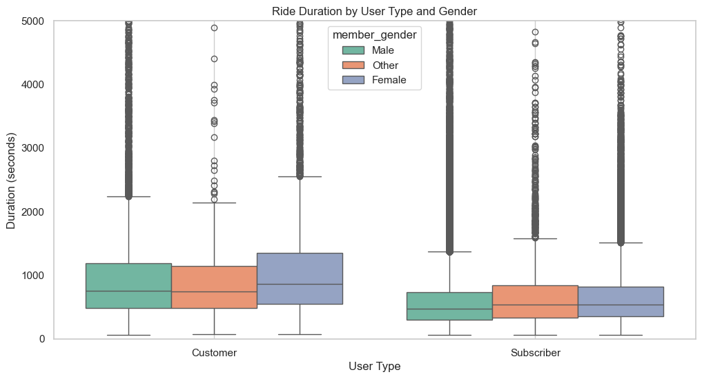

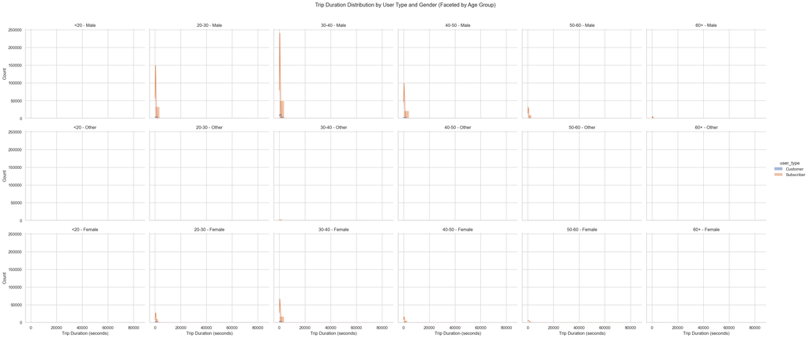

### 2. How does ride duration vary across different age groups for Customers and Subscribers, and what trends can be observed in each group?

Analyzes ride duration segmented by age groups and user types.

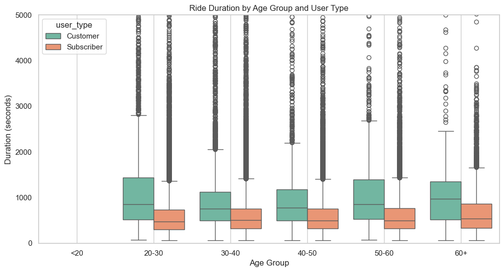

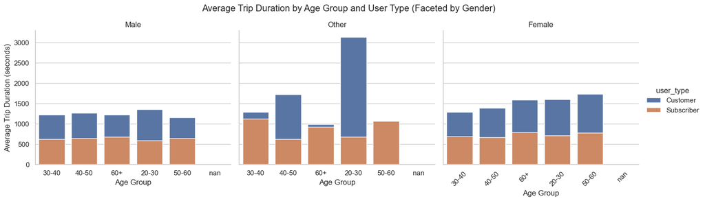

## Conclusions

The exploration of the bike ride dataset revealed several significant insights:

- **Ride Duration**: Predominantly short, with some outliers; this suggests that while many users take quick trips, there are also longer rides that might require additional operational focus.
- **User Type and Gender**: There is a strong skew towards subscribers and male users, pointing to potential marketing opportunities to attract more female and casual riders.
- **Age Analysis**: The age distribution suggests younger users are more engaged, but older demographics also show unique usage patterns that could be leveraged for targeted marketing.

Throughout this exploration, I utilized various visualizations to identify key trends and relationships in the dataset. By systematically examining each variable and its interactions with others, I gained a comprehensive understanding of user behaviors and preferences in bike-sharing usage. This structured approach to data exploration not only aids in identifying actionable insights but also sets the stage for further analysis or predictive modeling efforts in the future.

[output not shown]